# Test a Perceptual Phenomenon

### Analyzing the Stroop Effect

(1) What is the independent variable? What is the dependent variable?

the independant variables : Names of colors appeared in black ink( congruent), Names of colors in a different ink than the color named (incongruent) the dependant variables: the reaction time of the individuals

(2) What is an appropriate set of hypotheses for this task? Specify your null and alternative hypotheses, and clearly define any notation used. Justify your choices.

(3) Report some descriptive statistics regarding this dataset. Include at least one measure of central tendency and at least one measure of variability. The name of the data file is 'stroopdata.csv'.

```python
# Perform the analysis here
import pandas as pd
import numpy as np
import matplotlib.pyplot as plt
import scipy.stats

df= pd.read_csv('stroopdata.csv')
df.head()
```

|  | Congruent | Incongruent |
| --- | --- | --- |
| 0 | 12.079 | 19.278 |
| 1 | 16.791 | 18.741 |
| 2 | 9.564 | 21.214 |
| 3 | 8.630 | 15.687 |
| 4 | 14.669 | 22.803 |

```python
df.shape
```

```
(24, 2)
```

The test to be used in this case is a two sample paired T-Test and this because: we have 2 samples and we are trying to prouve that the difference between the two means (of each sample) is not random but there is a real difference in the reaction time between the 2 tests. In addition, we are using the paired T-test because the same individuals are used for experiments with congruent and incongruent words , we call it self pairing in this test, I assume that the distribution of the mean difference is normal, and also that the pairs of observations are indpendant and random.

```python
# measures of central tendency used : mean, median=second quartile
# measures of variability : standard deviation, min, max, first and third quartile

df.describe()
```

|  | Congruent | Incongruent |
| --- | --- | --- |
| count | 24.000000 | 24.000000 |
| mean | 14.051125 | 22.015917 |
| std | 3.559358 | 4.797057 |
| min | 8.630000 | 15.687000 |
| 25% | 11.895250 | 18.716750 |
| 50% | 14.356500 | 21.017500 |
| 75% | 16.200750 | 24.051500 |
| max | 22.328000 | 35.255000 |

```python
meanC= df['Congruent'].mean()
meanI= df['Incongruent'].mean()
varC = df['Congruent'].var()
varI = df['Incongruent'].var()
meanC, meanI, varC, varI
```

```
(14.051124999999999,
 22.015916666666666,
 12.669029070652176,
 23.011757036231884)
```

(4) Provide one or two visualizations that show the distribution of the sample data. Write one or two sentences noting what you observe about the plot or plots.

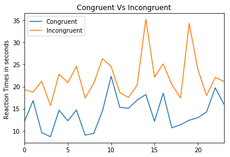

```python
# Build the visualizations here
df.plot()
plt.title('Congruent Vs Incongruent')
plt.ylabel('Reaction Times in seconds ');
```

In the graph I noticed that for all individuals it took longuer to react to the incongruent than it took them to react to the congruent words to the congruent.

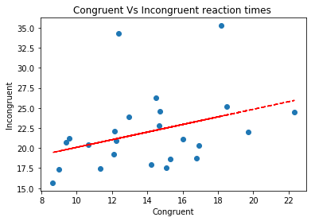

```python
x = df['Congruent']
y = df['Incongruent']
plt.scatter(x, y)
plt.ylabel('Incongruent')
plt.xlabel('Congruent')
plt.title('Congruent Vs Incongruent reaction times ');

z = np.polyfit(x, y, 1)
p = np.poly1d(z)
plt.plot(x,p(x),"r--");
```

I noticed that there is a positive correlation between congruent and incongruent reaction times.

(5) Now, perform the statistical test and report your results. What is your confidence level or Type I error associated with your test? What is your conclusion regarding the hypotheses you set up? Did the results match up with your expectations? **Hint:** Think about what is being measured on each individual, and what statistic best captures how an individual reacts in each environment.

```python
# Perform the statistical test here
# Alpha = 0.05, so if P-value <= alpha we reject the H0, if not than we fail to reject H0
# the confidence level is 95%
# the variances are inequal
scipy.stats.ttest_rel (x,y)
```

```
Ttest_relResult(statistic=-8.020706944109957, pvalue=4.1030005857111781e-08)
```